# Analysis on salary of Kaggle 2020 survey

## by Baiyan Ren

## Investigation Overview

> Understand the salary of data science and machine learning practitioners.

## Dataset Overview

> This dataset is the annual survey of Kaggle on data science and machine learning in 2020. It collects the information of prectitioners in a comprehensive way, from age, gender to prefered machine learning tools.

## (Visualization 1)

> The most common education level is Bachelor and Master's degree.

Next, I'll explore the relationship of these variables.

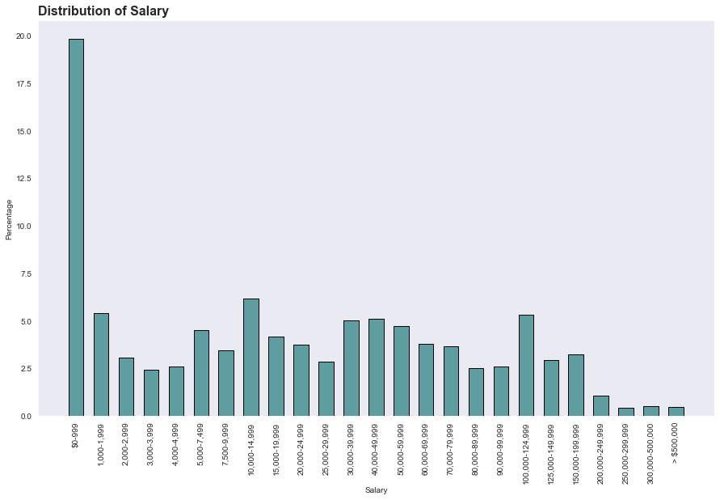

```python
sns.set_style('dark')
fig, ax = plt.subplots(figsize=[15, 9])
ax.bar(salary_total.index, salary_prop_total, color='cadetblue', edgecolor=(0, 0, 0), width=0.6, label='All')



plt.xticks(rotation=90)
plt.xlabel('Salary')
plt.ylabel('Percentage')
plt.title('Distribution of Salary', fontsize=16, fontweight='bold', loc='left');
```

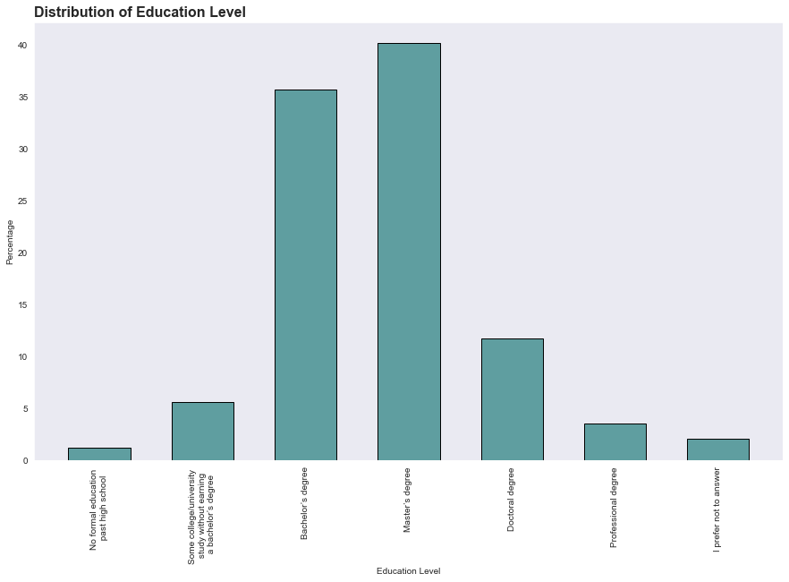

```python
sns.set_style('dark')
fig, ax = plt.subplots(figsize=[15, 9])
ax.bar(edu_prop.index, edu_prop, color='cadetblue', edgecolor=(0, 0, 0), width=0.6, label='All')

edu_label = ['No formal education \n past high school',
             'Some college/university \n study without earning \n a bachelor’s degree',
             'Bachelor’s degree',
             'Master’s degree',
             'Doctoral degree',
             'Professional degree',
             'I prefer not to answer']

locs, labels = plt.xticks()
plt.xticks(rotation=90, ticks = locs, labels=edu_label)
plt.xlabel('Education Level')
plt.ylabel('Percentage')
plt.title('Distribution of Education Level', fontsize=16, fontweight='bold', loc='left');
```

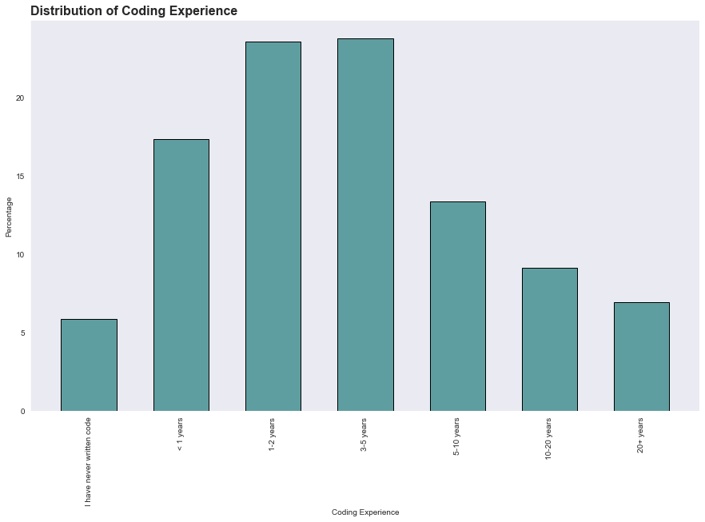

```python
sns.set_style('dark')
fig, ax = plt.subplots(figsize=[15, 9])
ax.bar(coding_prop.index, coding_prop, color='cadetblue', edgecolor=(0, 0, 0), width=0.6, label='All')
plt.xticks(rotation=90)
plt.xlabel('Coding Experience')
plt.ylabel('Percentage')
plt.title('Distribution of Coding Experience', fontsize=16, fontweight='bold', loc='left');
```

## (Visualization 2)

> Coding experience increases with education level.

> The interesting part is, the period of time to complete the survey is different among education levels.

Next, I'll explore further into these variables.

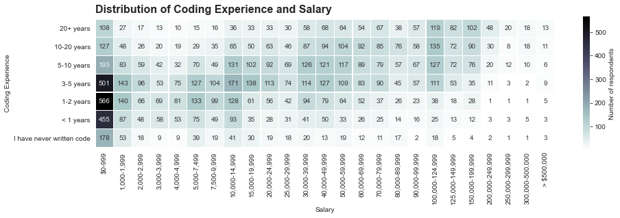

```python
sns.set_style('dark')
fig, ax = plt.subplots(figsize=[15, 9])

sns.heatmap(data=coding_salary,
                  cmap='bone_r',
                  linewidths=0.2,
                  square=True,
                  annot=True,
                  fmt = 'd',
                  annot_kws={'alpha': 0.9},
                  cbar_kws={'shrink': 0.4, 'label': 'Number of respondents'})
plt.xlabel('Salary')

plt.ylabel('Coding Experience')

plt.title('Distribution of Coding Experience and Salary', fontsize=16, fontweight='bold', loc='left', va='bottom');
```

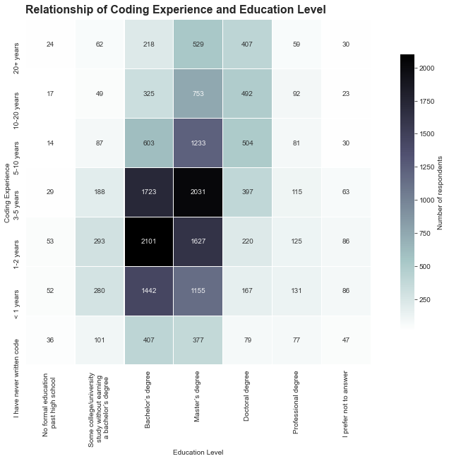

```python
sns.set_style('dark')
fig, ax = plt.subplots(figsize=[15, 9])

sns.heatmap(data=coding_edu,
                  cmap='bone_r',
                  linewidths=0.2,
                  square=True,
                  annot=True,
                  fmt = 'd',
                  annot_kws={'alpha': 0.9},
                  cbar_kws={'shrink': 0.8, 'label': 'Number of respondents'})
locs, labels = plt.xticks()
plt.xticks(rotation=90, ticks = locs, labels=edu_label)
plt.xlabel('Education Level')

plt.ylabel('Coding Experience')

plt.title('Relationship of Coding Experience and Education Level', fontsize=16, fontweight='bold', loc='left', va='bottom');
```

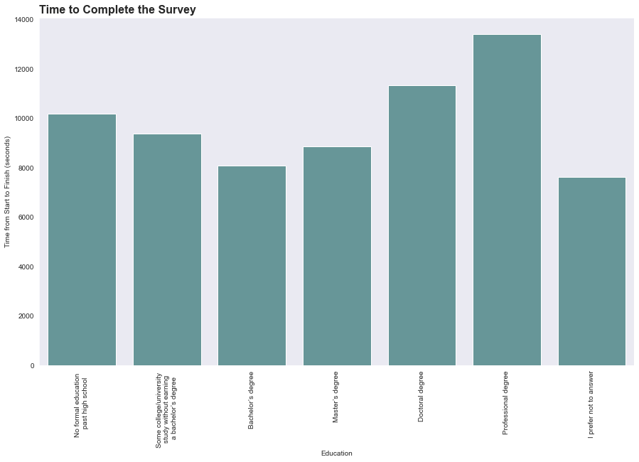

```python
sns.set_style('dark')
fig, ax = plt.subplots(figsize=[15, 9])
sns.barplot(data=survey_2020, x='Education', y='Time from Start to Finish (seconds)', ci=None, color='cadetblue')
locs, labels = plt.xticks()
plt.xticks(rotation=90, ticks = locs, labels=edu_label)

plt.xlabel('Education')
plt.title('Time to Complete the Survey', fontsize=16, fontweight='bold', loc='left');
```

## (Visualization 3)

> There is positive correlation between salary and coding experience in all three education levels. In addition, with the same coding experience, the salary of respondents with doctoral degree is higher than those with Master's degree and Bachelor's degree.

> For the time to complete the survey, there are differences among education level, gender and coding experience.

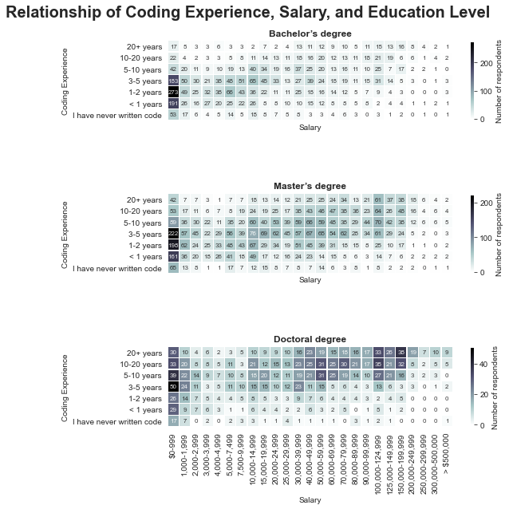

```python
fig, axes = plt.subplots(3, 1, figsize=[8, 10], sharex=True, sharey=True)

ax1 = sns.heatmap(data=coding_bs,
                  cmap='bone_r',
                  linewidths=0.2,
                  square=True,
                  annot=True,
                  fmt = 'd',
                  annot_kws={'alpha': 0.9, 'fontsize': 8},
                  cbar_kws={'shrink': 0.6, 'label': 'Number of respondents'},
                  ax=axes[0],
                  label='Bachelor’s degree')
ax2 = sns.heatmap(data=coding_ms,
                  cmap='bone_r',
                  linewidths=0.2,
                  square=True,
                  annot=True,
                  fmt = 'd',
                  annot_kws={'alpha': 0.9, 'fontsize': 8},
                  cbar_kws={'shrink': 0.6, 'label': 'Number of respondents'},
                  ax=axes[1],
                  label='Master’s degree')
ax3 = sns.heatmap(data=coding_doct,
                  cmap='bone_r',
                  linewidths=0.2,
                  square=True,
                  annot=True,
                  fmt = 'd',
                  annot_kws={'alpha': 0.9, 'fontsize': 8},
                  cbar_kws={'shrink': 0.6, 'label': 'Number of respondents'},
                  ax=axes[2],
                  label='Doctoral degree')
fontdict={'fontsize': 12,
          'fontweight': 'bold'}
ax1.set_title('Bachelor’s degree', fontdict=fontdict)
ax2.set_title('Master’s degree', fontdict=fontdict)
ax3.set_title('Doctoral degree', fontdict=fontdict)
for ax in [ax1, ax2, ax3]:
    ax.set_ylabel('Coding Experience')

fig.suptitle('Relationship of Coding Experience, Salary, and Education Level', x=0.3, y=0.9, size=20, weight='bold');
```

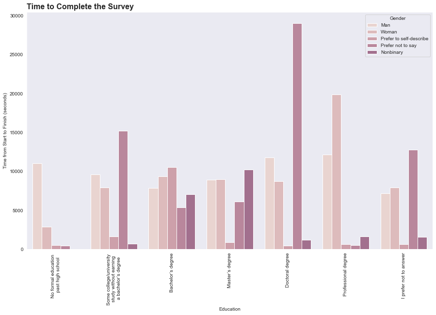

```python
fig, ax = plt.subplots(figsize=[15, 9])
sns.barplot(data=survey_2020, x='Education', y='Time from Start to Finish (seconds)', hue='Gender', ci=None, palette=cmap)
locs, labels = plt.xticks()
plt.xticks(rotation=90, ticks = locs, labels=edu_label)
plt.xlabel('Education')
plt.title('Time to Complete the Survey', fontsize=16, fontweight='bold', loc='left');
```

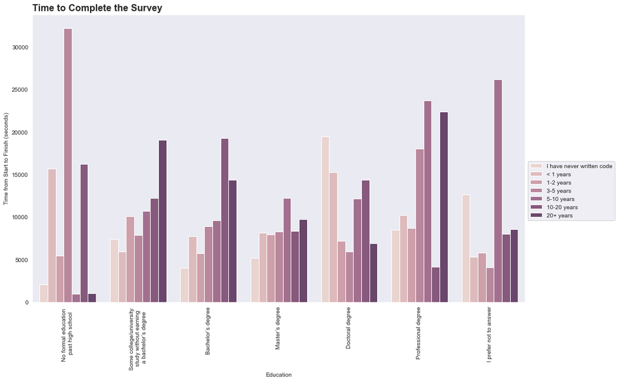

```python
fig, ax = plt.subplots(figsize=[15, 9])
sns.barplot(data=survey_2020, x='Education', y='Time from Start to Finish (seconds)', hue='Coding_exp', ci=None, palette=cmap)
locs, labels = plt.xticks()
plt.xticks(rotation=90, ticks = locs, labels=edu_label)
plt.xlabel('Education')
plt.legend(bbox_to_anchor=[1, 0.5, 0, 0])
plt.title('Time to Complete the Survey', fontsize=16, fontweight='bold', loc='left');
```